# CySESH Shortening Project [1]

# RSM Analysis

First, we look at the model summary and save it as a data frame for later.

```r
smr_r <- summary(fit_r) |> as.data.frame()
```

```
                          F1    h2
cy_sesh_policies1      0.771 0.595
cy_sesh_deletion3      0.677 0.459
cy_sesh_deletion1      0.744 0.553
cy_sesh_communication3 0.716 0.512
cy_sesh_collection1    0.771 0.594
cy_sesh_understanding1 0.634 0.402
cy_sesh_connecting1    0.818 0.669
cy_sesh_patterns4      0.701 0.491
cy_sesh_patterns5      0.775 0.600
cy_sesh_help1          0.625 0.390
cy_sesh_purchase3      0.745 0.555
cy_sesh_threats5       0.610 0.372

SS loadings:  6.192
Proportion Var:  0.516

Factor correlations:

   F1
F1  1
```

F1 represents the factor loadings for each item, h2 represents the communality, i.e. how much of the item’s variance is explained by the latent factor.

Next, we look at parameters in our model. Note that a rating scale model assumes ordered items from bad to good, in a sense. again, we save it as a data frame for later

```r
ice_r <- coef(fit_r, simplify =T)|> as.data.frame()
ice_r
```

|  | items.a1 | items.b1 | items.b2 | items.b3 | items.b4 | items.b5 | items.b6 | items.c | means | F1 |
| --- | --- | --- | --- | --- | --- | --- | --- | --- | --- | --- |
| cy_sesh_policies1 | 2.063407 | 2.176994 | 1.30899 | 0.5066005 | -0.437821 | -1.122258 | -1.836252 | 0.0000000 | 0 | 1 |
| cy_sesh_deletion3 | 1.567645 | 2.176994 | 1.30899 | 0.5066005 | -0.437821 | -1.122258 | -1.836252 | 0.4313247 | 0 | 1 |
| cy_sesh_deletion1 | 1.892613 | 2.176994 | 1.30899 | 0.5066005 | -0.437821 | -1.122258 | -1.836252 | 0.4832066 | 0 | 1 |
| cy_sesh_communication3 | 1.743151 | 2.176994 | 1.30899 | 0.5066005 | -0.437821 | -1.122258 | -1.836252 | -0.4674858 | 0 | 1 |
| cy_sesh_collection1 | 2.060650 | 2.176994 | 1.30899 | 0.5066005 | -0.437821 | -1.122258 | -1.836252 | 0.1807913 | 0 | 1 |
| cy_sesh_understanding1 | 1.395738 | 2.176994 | 1.30899 | 0.5066005 | -0.437821 | -1.122258 | -1.836252 | 0.1986761 | 0 | 1 |
| cy_sesh_connecting1 | 2.417582 | 2.176994 | 1.30899 | 0.5066005 | -0.437821 | -1.122258 | -1.836252 | -0.1565963 | 0 | 1 |
| cy_sesh_patterns4 | 1.670868 | 2.176994 | 1.30899 | 0.5066005 | -0.437821 | -1.122258 | -1.836252 | -0.2655308 | 0 | 1 |
| cy_sesh_patterns5 | 2.083907 | 2.176994 | 1.30899 | 0.5066005 | -0.437821 | -1.122258 | -1.836252 | -0.5798143 | 0 | 1 |
| cy_sesh_help1 | 1.360988 | 2.176994 | 1.30899 | 0.5066005 | -0.437821 | -1.122258 | -1.836252 | -0.2986668 | 0 | 1 |
| cy_sesh_purchase3 | 1.901257 | 2.176994 | 1.30899 | 0.5066005 | -0.437821 | -1.122258 | -1.836252 | 0.3707902 | 0 | 1 |
| cy_sesh_threats5 | 1.309304 | 2.176994 | 1.30899 | 0.5066005 | -0.437821 | -1.122258 | -1.836252 | 0.5836785 | 0 | 1 |

b parameters represent the theta thresholds at which a person is about as likely to choose one or the next-lower option. a represents the discrimination parameter (higher means, it can distinguish thetas better). c is the guessing parameter for each item. Parameters are the same for each item in the RSM. Unfortunately, our threshold order got reversed here. This is a known phenomenon sometimes referred to as “negative deltas” (cf. Adams et al., 2012; Wetzel & Carstensen, 2014), the explanation of which is hard to specifically pin-point in our case. According to Adams et al.(2012), possible explanations in our case could be variation in discrimination parameters of adjacent categories or low frequencies of certain answer categories.

Looking at Item Histograms, we do have rather low counts in the first answer category:

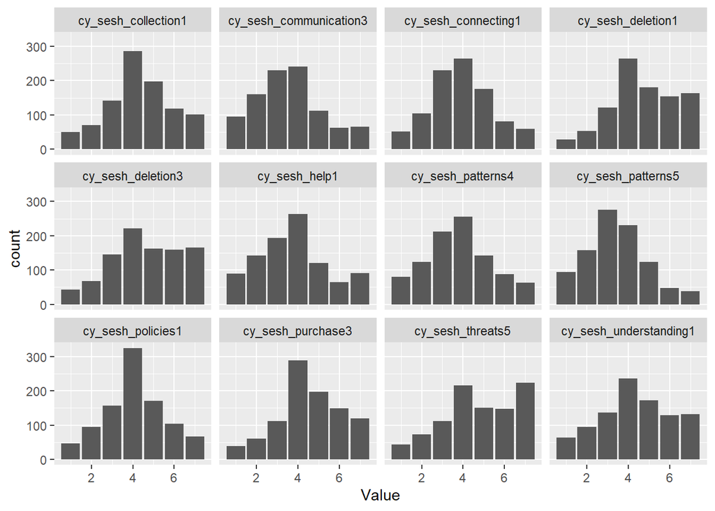

```r
rdata[,c(items,which(colnames(rdata)=="id"))] |> pivot_longer(cols = colnames(rdata[,c(items,which(colnames(rdata)=="id"))][1:12]), names_to = "Item", values_to = "Value") |> ggplot()+aes(x=Value)+geom_bar()+facet_wrap(~Item)
```

We also have somewhat differing discrimination parameters between the patterns items and overall high-ish discrimination variance from 1.3 to 2.4. These items therefore must be looked at closely.

Next we assess model fit of the RSM. This has been calculated beforehand, as covergence takes some time. The following code was used:

````markdown
```{r}
modfit_r <- M2(fit_r, type = "C2", calcNull = F)
modfit_r
```
````

```r
modfit_r
```

|  | M2 | df | p | RMSEA | RMSEA_5 | RMSEA_95 | SRMSR |
| --- | --- | --- | --- | --- | --- | --- | --- |
| stats | 447.5283 | 109 | 0 | 0.0567604 | 0.0513223 | 0.0622477 | 0.0580837 |

Values of model fit are in acceptable ranges. Note that this is the standard RMSEA, NOT the $RMSEA_2$, as proposed by Maydeu-Olivares & Joe (2014) for IRT Models. M2 statistic (similar function as $\chi^2$) is significant, meaning that it would reject the model. However, M2 does not work properly for large models like ours (also stated in Maydeu-Olivares & Joe (2014)).

To follow-up, we assess item fit. This is done with the ´itemfit()´command.

```r
itf_r <- itemfit(fit_r)
itf_r
```

| item | S_X2 | df.S_X2 | RMSEA.S_X2 | p.S_X2 |
| --- | --- | --- | --- | --- |
| cy_sesh_policies1 | 166.4180 | 157 | 0.0078884 | 0.2881941 |
| cy_sesh_deletion3 | 163.2033 | 172 | 0.0000000 | 0.6723860 |
| cy_sesh_deletion1 | 165.5700 | 152 | 0.0096234 | 0.2135283 |
| cy_sesh_communication3 | 139.6468 | 173 | 0.0000000 | 0.9704094 |
| cy_sesh_collection1 | 190.0756 | 148 | 0.0171730 | 0.0111879 |
| cy_sesh_understanding1 | 197.1142 | 196 | 0.0024283 | 0.4642106 |
| cy_sesh_connecting1 | 172.0298 | 134 | 0.0171582 | 0.0148677 |
| cy_sesh_patterns4 | 226.3801 | 175 | 0.0174518 | 0.0053741 |
| cy_sesh_patterns5 | 156.5690 | 148 | 0.0077499 | 0.2989790 |
| cy_sesh_help1 | 209.2063 | 189 | 0.0105311 | 0.1495377 |
| cy_sesh_purchase3 | 181.6215 | 153 | 0.0139304 | 0.0568723 |
| cy_sesh_threats5 | 203.4077 | 182 | 0.0110461 | 0.1323212 |

this computes the S_X2 statistic, which should not become significant for items in order to signify good fit. This will be discussed later on.

Finally, Let’s look at a plot for the whole model in terms of total scores in relation to theta.

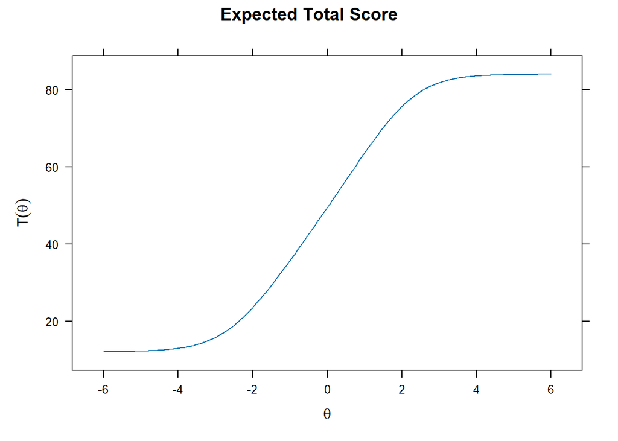

```r
plot(fit_r)
```

**Infit and Outfit**

Items usually are looked at in terms of infit and outfit statistics. In general, it is preferable to look at infit, which should be close to 1, and ideally less than 1. To visualize this for all items, we additionally use the `itemfitplot()` function from `ggmirt`.

```r
infi_r <- itemfit(fit_r, fit_stats = "infit") |> as.data.frame()
infi_r
```

| item | outfit | z.outfit | infit | z.infit |
| --- | --- | --- | --- | --- |
| cy_sesh_policies1 | 0.9237367 | -1.4518274 | 0.9279195 | -1.4466962 |
| cy_sesh_deletion3 | 0.9422703 | -1.1367531 | 0.9227905 | -1.7010961 |
| cy_sesh_deletion1 | 0.9089026 | -1.6754035 | 0.9191600 | -1.6861899 |
| cy_sesh_communication3 | 0.9280862 | -1.3961225 | 0.9379025 | -1.2747654 |
| cy_sesh_collection1 | 0.8686341 | -2.5287142 | 0.8800128 | -2.4778024 |
| cy_sesh_understanding1 | 1.0006567 | 0.0296449 | 0.9622354 | -0.8530173 |
| cy_sesh_connecting1 | 0.8698023 | -2.4512675 | 0.8764542 | -2.4410850 |
| cy_sesh_patterns4 | 1.0165477 | 0.3434206 | 0.9905286 | -0.1824292 |
| cy_sesh_patterns5 | 0.9114822 | -1.6262458 | 0.9233041 | -1.5063789 |
| cy_sesh_help1 | 1.0345260 | 0.7417993 | 0.9791395 | -0.4593022 |
| cy_sesh_purchase3 | 0.9515313 | -0.8914892 | 0.9496435 | -1.0309506 |
| cy_sesh_threats5 | 0.9698949 | -0.6036893 | 0.9730365 | -0.6080901 |

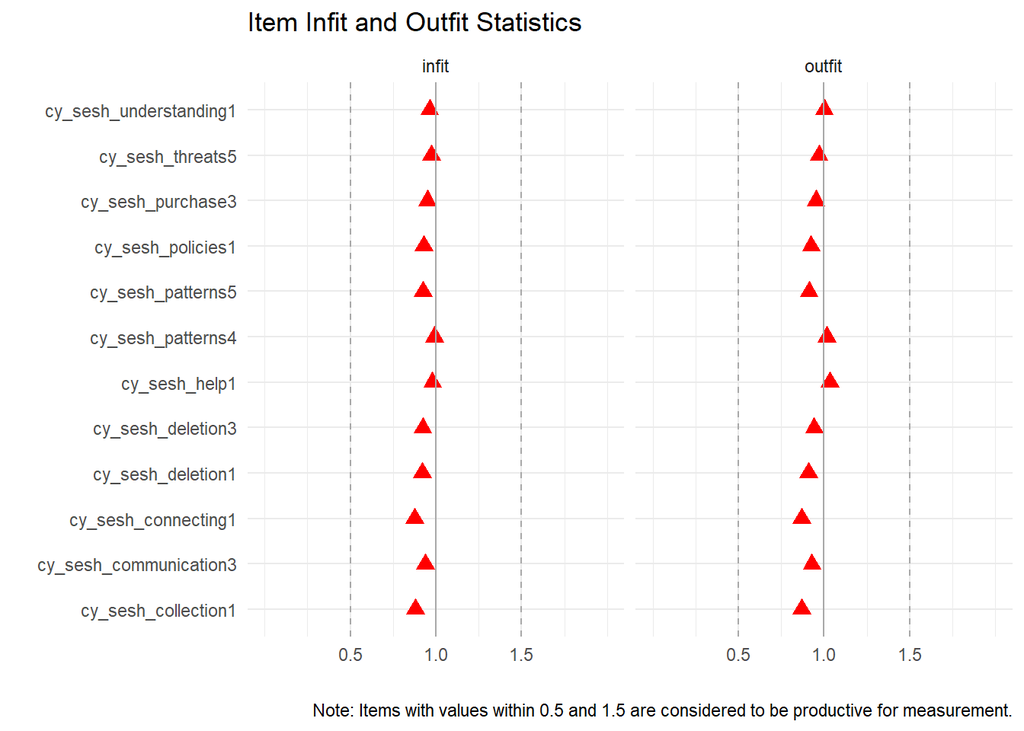

```r
itemfitPlot(fit_r)
```

As one can see from these data, our items seem to be fine in regard to infit.

**Person Fit**

To calculate whether the persons fit the model, we use person fit statistics. We calculate proportions of infit and outfit in persons using z-scores. Higher non-fitting rates than 5% are considered worrying.

```r
personfit(fit_r) |>
  reframe(infit.outside = prop.table(table(z.infit > 1.96 | z.infit < -1.96)),
          outfit.outside = prop.table(table(z.outfit>1.96 | z.outfit < -1.96)))
```

| infit.outside | outfit.outside |
| --- | --- |
| 0.7958549 | 0.8 |
| 0.2041451 | 0.2 |

The bottom row represents non-fitting people. As we can see, we have about 4x the acceptable amount of people not fitting to the model. This is a worrying amount and may explain the somewhat bad-ish fit values.

To further investigate this, we can plot the factor scores.

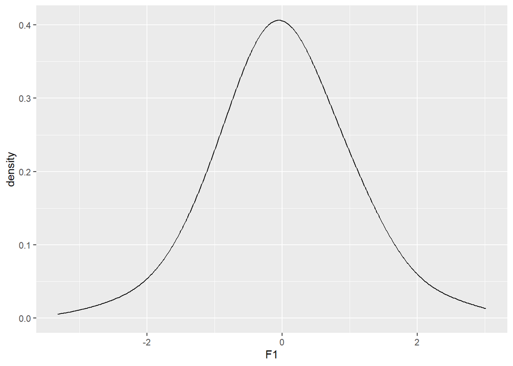

```r
fscores(fit_r) |> as.data.frame() |> ggplot(aes(F1))+geom_density(bw=0.5)
```

This is a smoothed kernel density plot of estimated factor scores of all persons in the data set. As we can see, extreme ends are fatter than would be expected with normal distributed ends.

Let’s look at an un-smoothed version of this.

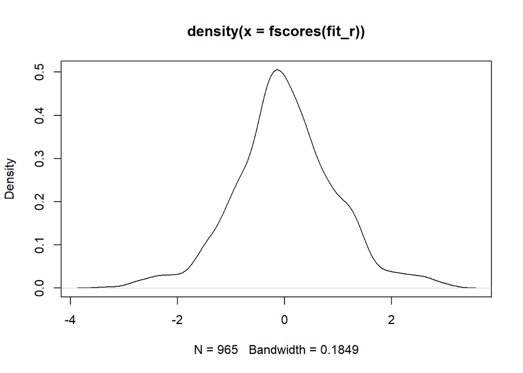

```r
fscores(fit_r) |> density() |> plot()
```

The plot clearly shows outliers at the extreme ends in both directions. The question remains whether this was a sampling problem or a modeling issue - this can only be solved by further sampling.

To investigate further, we look at the specific people with factor scores higher or lower than |2| (high or low thetas), extract them and group them into data frames.

```r
#construct dfs with high or low theta scores
unfit_top <- rdata[which(fscores(fit_r)>2),]
unfit_bot <- rdata[which(fscores(fit_r)< -2),]
```

Then we boxplot the CySESH scores of these and look at demographic influence for funsies.

```
Notch went outside hinges
ℹ Do you want `notch = FALSE`?
Notch went outside hinges
ℹ Do you want `notch = FALSE`?
Notch went outside hinges
ℹ Do you want `notch = FALSE`?
```

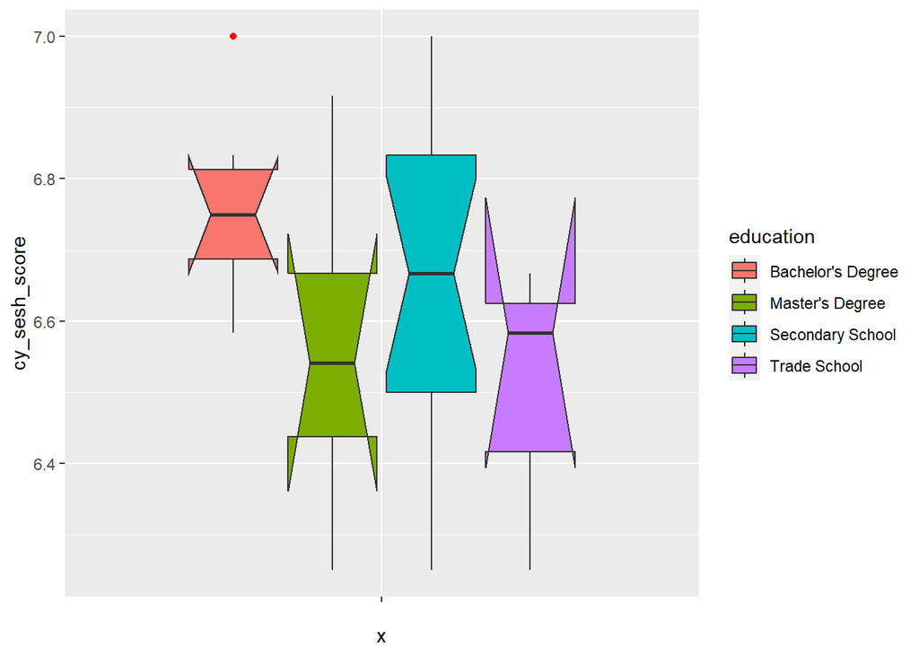

```r
#plot and show scores of that data by education.
unfit_top |> ggplot(aes(y=cy_sesh_score, x="", fill = education))+geom_boxplot(notch = T, outlier.colour = "red")
```

```
Notch went outside hinges
ℹ Do you want `notch = FALSE`?
Notch went outside hinges
ℹ Do you want `notch = FALSE`?
Notch went outside hinges
ℹ Do you want `notch = FALSE`?
```

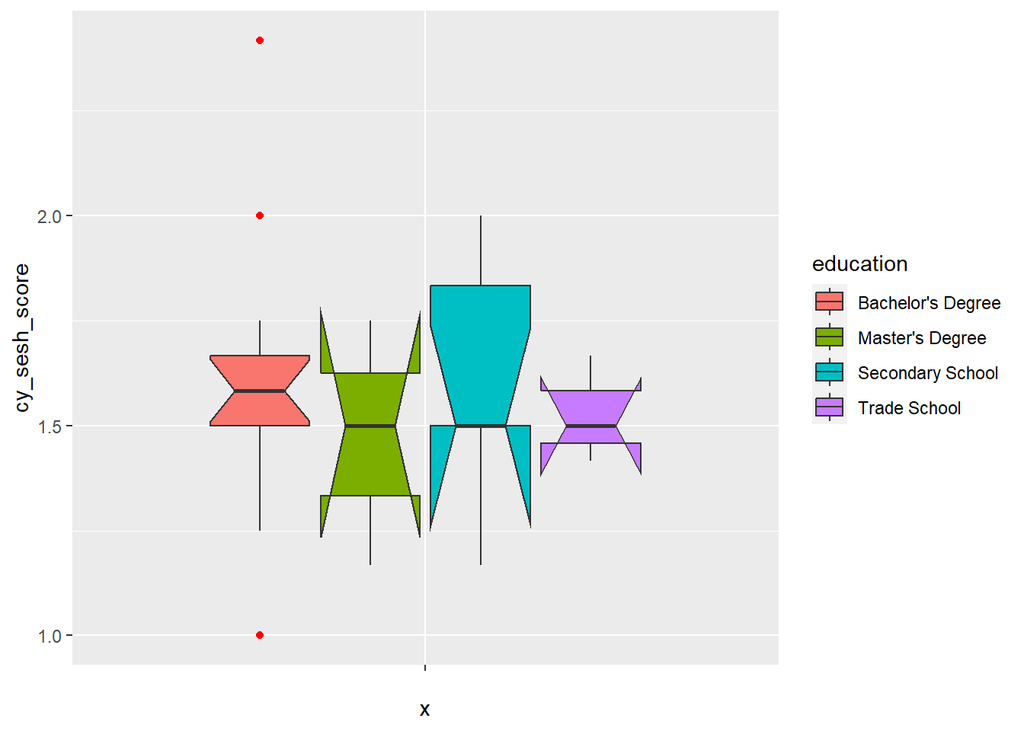

```r
unfit_bot |> ggplot(aes(y=cy_sesh_score, x="", fill = education))+geom_boxplot(notch = T, outlier.colour = "red")
```

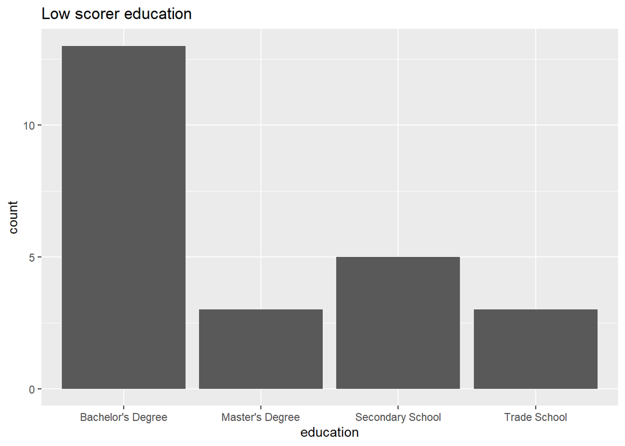

```r
unfit_bot |> ggplot(aes(x=education))+geom_bar() + labs(title = "Low scorer education")
```

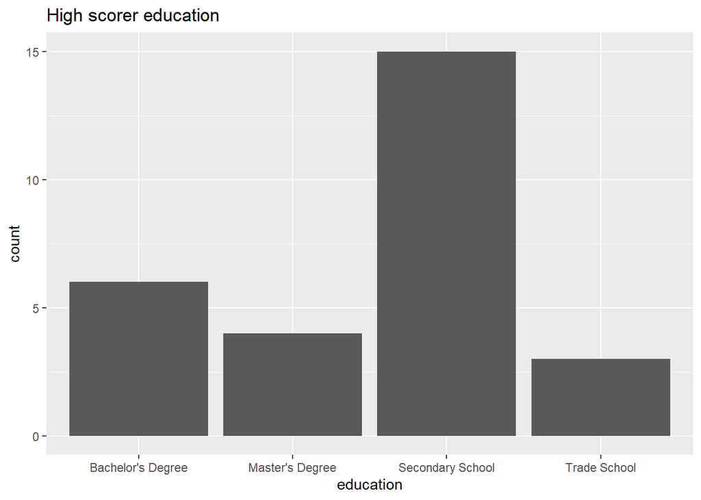

```r
unfit_top |> ggplot(aes(x=education))+geom_bar() + labs(title = "High scorer education")
```

Bottom and Top scorer’s CySESH values range between the lowest or highest two options, respectively. Variability does not really correlate well with education level for both scenarios. Bottom scorers show low variability in data, which suggests higher confidence in own ability estimates (i.e. being terrible with smart home security). Bar plots indicate that low scorers consist of more highly educated individuals, while high scorers show higher proportions of lesser educated participants. This is expected from an ability overestimation/underestimation viewpoint, a phenomenon previously described in literature (Kim et al., 2016)

Now let’s see whether age is associated with this.

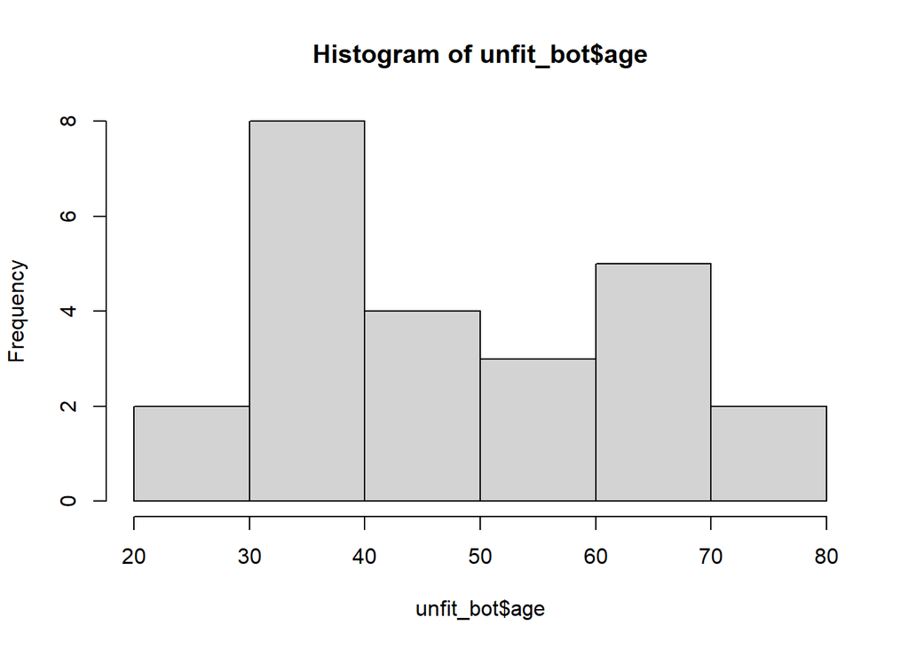

```r
unfit_bot$age |> hist()
```

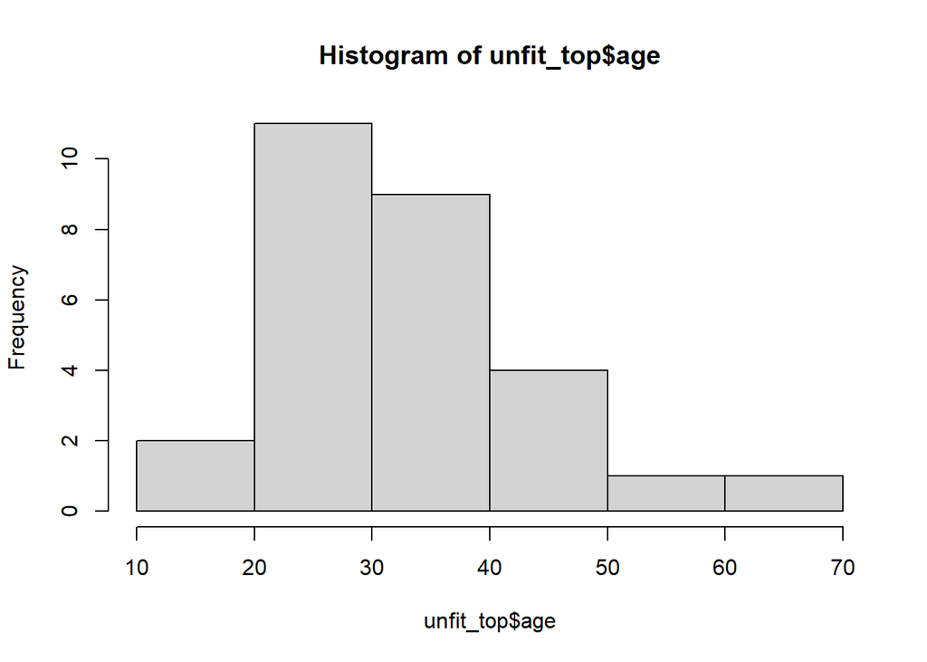

```r
unfit_top$age |> hist()
```

Top scorers are rather young while low scorers don’t show any clear relationship. This is expected since many younger people have more experience growing up with digital tech and smart homes in general. Technology exposure/use is known to increase better security knowledge (Lee & Chua, 2023) and therefore seems likely to influence self-efficacy statements as well, as those variables seem to be linked (De Kimpe et al., 2022).

I would suggest a sensitivity analysis with outliers removed in the next round of sampling to see whether this influence biases results, and to which degree.

**Graphic Item Analysis**

Item analysis is done graphically and numerically with a final table. This is done to assess item quality for scale reduction. First, lets look at option characteristic curves (OCCs) for each item.

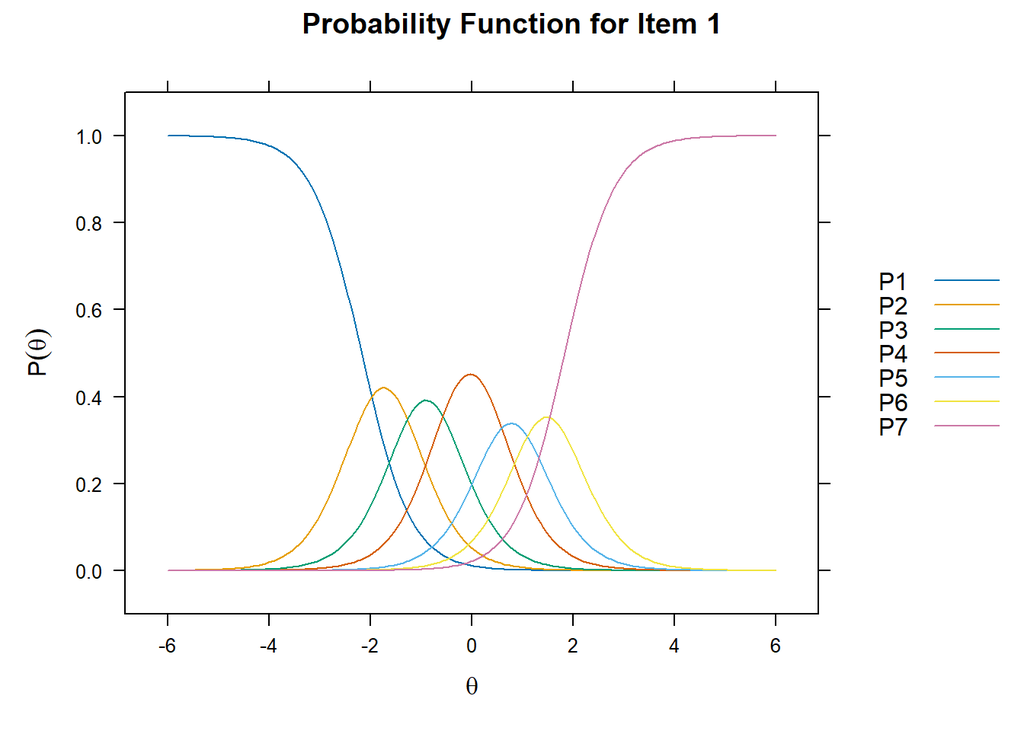

```r
#Option characteristic curves
itemplot(fit_r, item = 1)
```

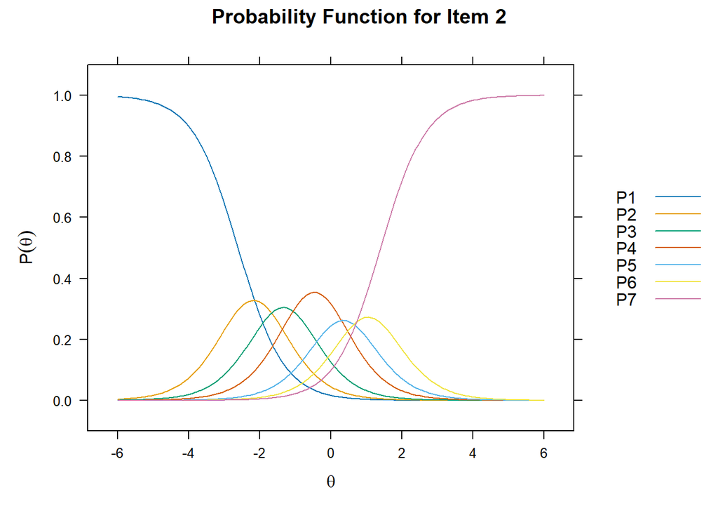

```r
itemplot(fit_r, item = 2)
```

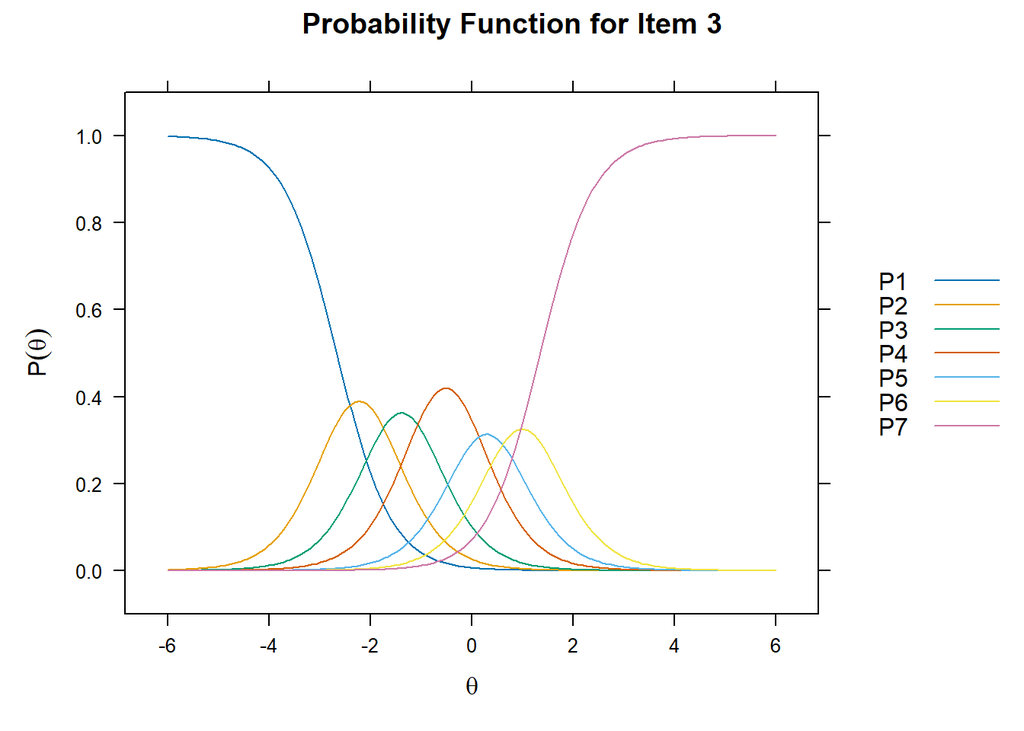

```r
itemplot(fit_r, item = 3)
```

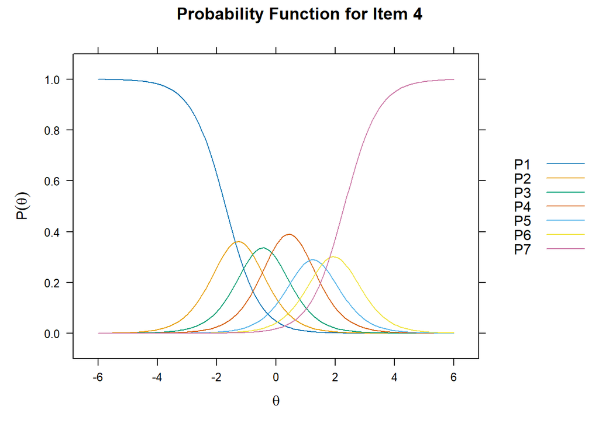

```r
itemplot(fit_r, item = 4)
```

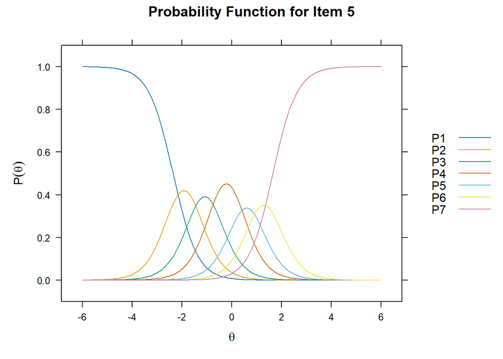

```r
itemplot(fit_r, item = 5)
```

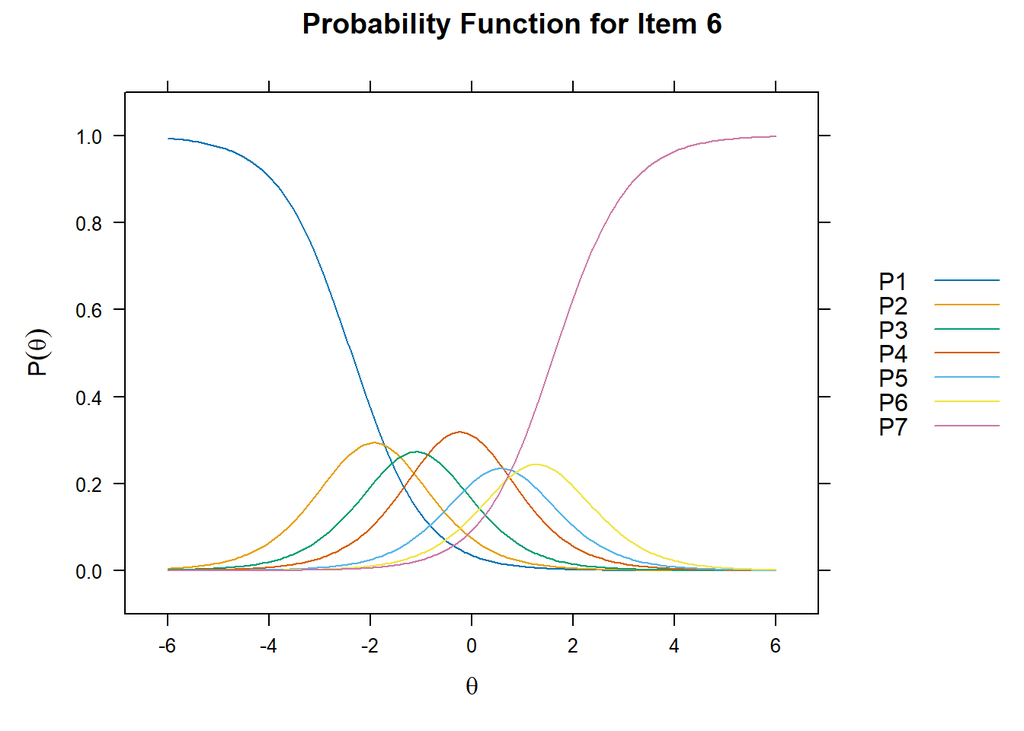

```r
itemplot(fit_r, item = 6)
```

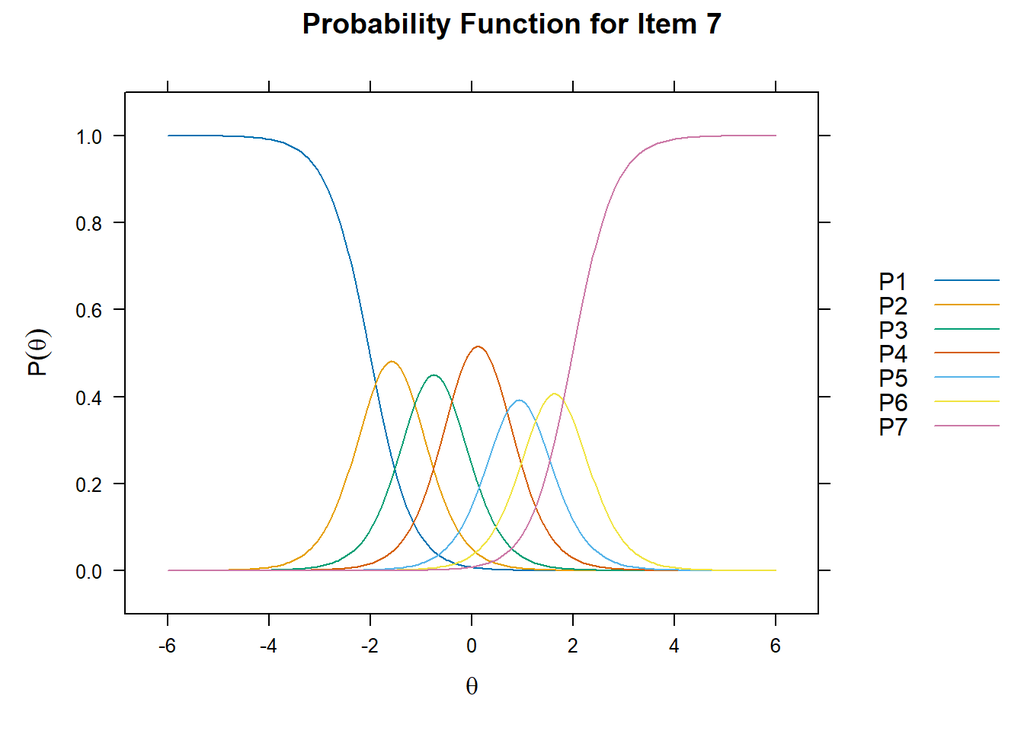

```r
itemplot(fit_r, item = 7)
```

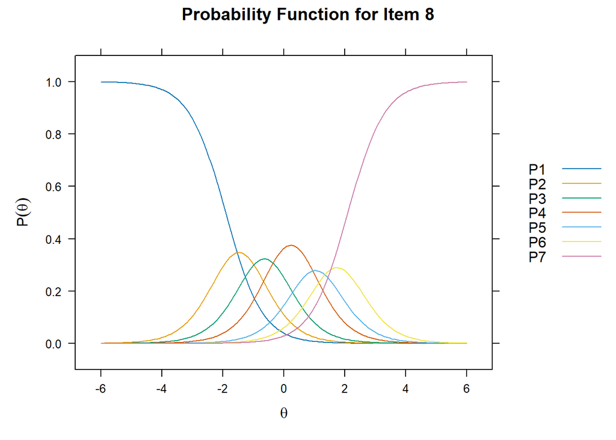

```r
itemplot(fit_r, item = 8)
```

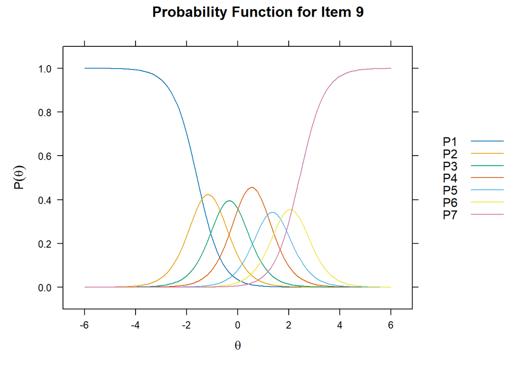

```r
itemplot(fit_r, item = 9)
```

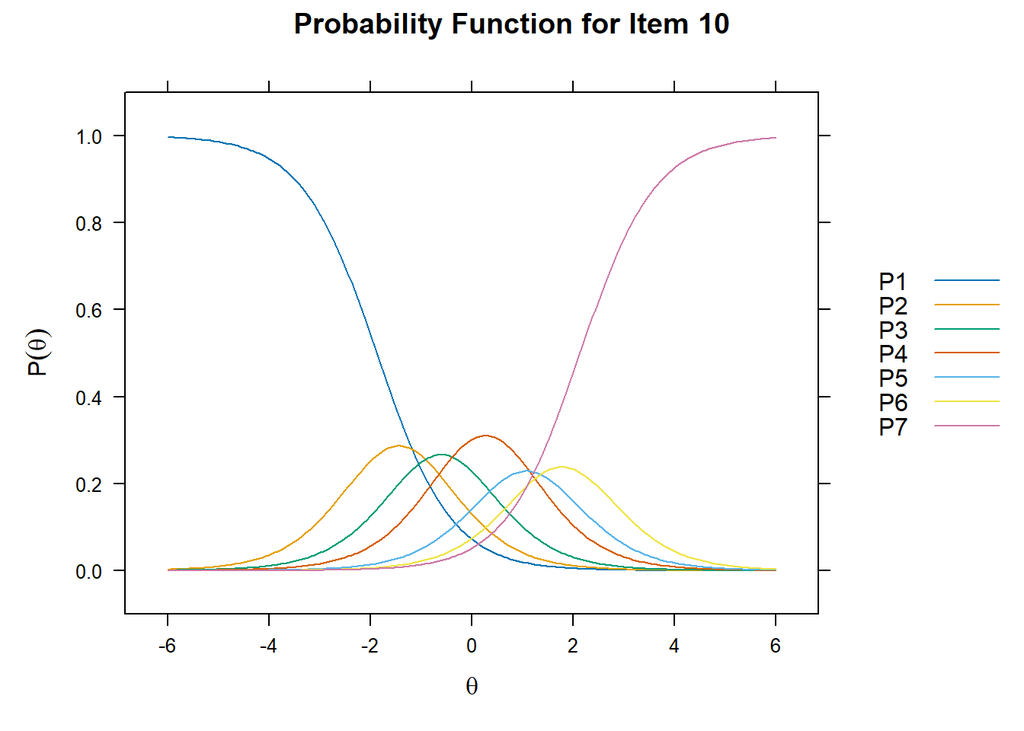

```r
itemplot(fit_r, item = 10)
```

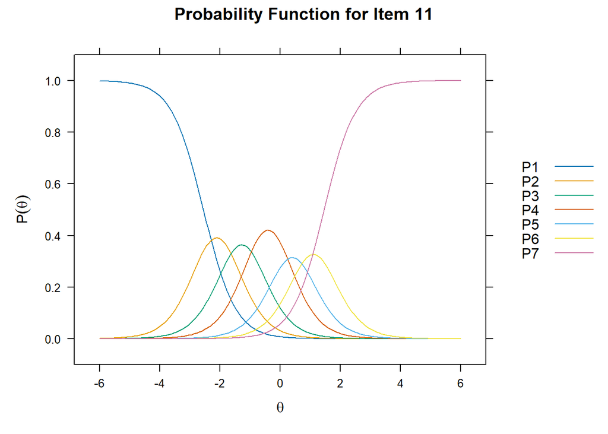

```r
itemplot(fit_r, item = 11)
```

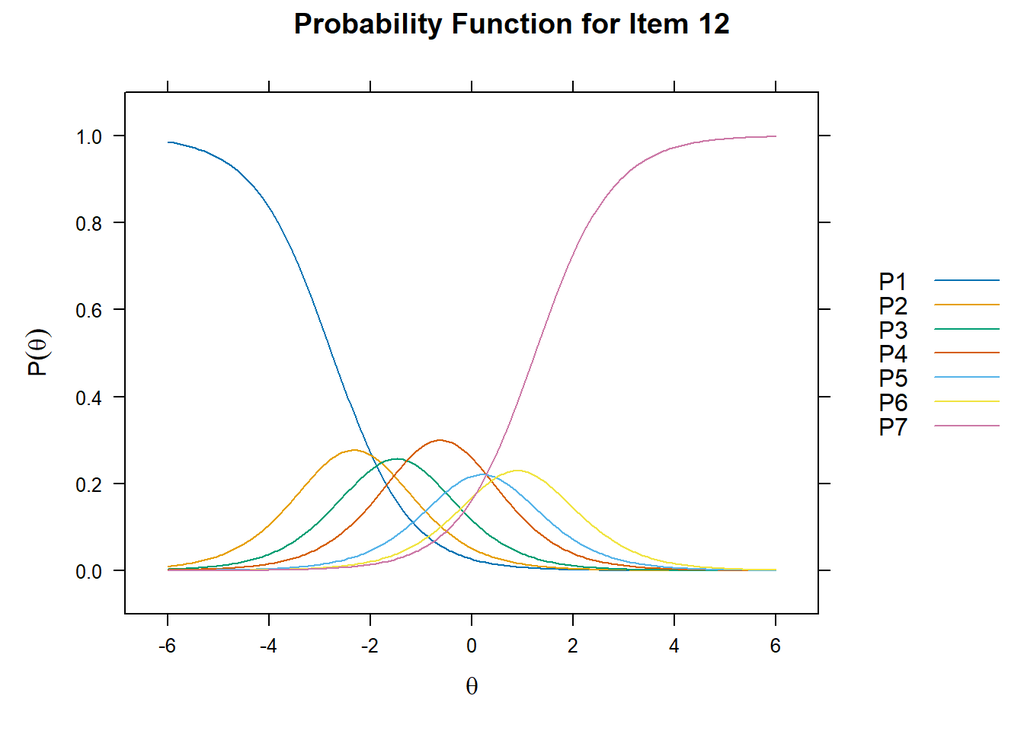

```r
itemplot(fit_r, item = 12)
```

In the figures we can see a probability density function for each answer option (1 to 7) within an item. Ideally, the mid-option peaks around a theta of zero and the other peaks are not overshadowed by other function curves. My interpretation of item aptitude for the short scale is the following:

1. ok
2. bad: skewed to negative theta
3. bad: skewed to negative theta
4. bad: skewed to positive theta.
5. ok, but lower difficulty.
6. ok, but more problematic, low discrimination on the upper end.
7. really good
8. bad: probability of extreme ends is higher than category before (overshadowing extremes).
9. bad: skewed to positive theta.
10. bad: overshadowing extremes.
11. bad: skewed to negative theta.
12. bad: skewed to negative theta + overshadowing extremes.

Additionally, we can plot the item information function for each item.

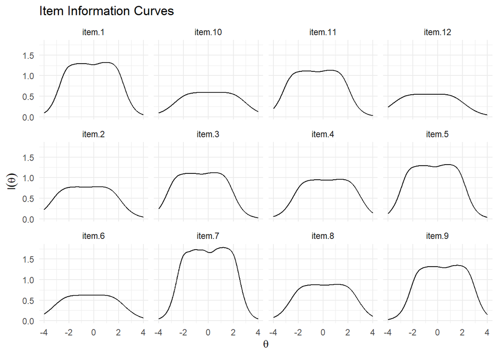

```r
itemInfoPlot(fit_r, facet = T)
```

```r
itemjudge <- data.frame(
  item = row.names(ice_r),
  communality = round(smr_r$h2, digits = 2),
  p.S_x2 = round(itf_r$p.S_X2, digits = 2),
  discr=round(ice_r$items.a1, digits = 2),
  infit= round(infi_r$infit, digits = 2)
)
itemjudge
```

| item | communality | p.S_x2 | discr | infit |
| --- | --- | --- | --- | --- |
| cy_sesh_policies1 | 0.60 | 0.29 | 2.06 | 0.93 |
| cy_sesh_deletion3 | 0.46 | 0.67 | 1.57 | 0.92 |
| cy_sesh_deletion1 | 0.55 | 0.21 | 1.89 | 0.92 |
| cy_sesh_communication3 | 0.51 | 0.97 | 1.74 | 0.94 |
| cy_sesh_collection1 | 0.59 | 0.01 | 2.06 | 0.88 |
| cy_sesh_understanding1 | 0.40 | 0.46 | 1.40 | 0.96 |
| cy_sesh_connecting1 | 0.67 | 0.01 | 2.42 | 0.88 |
| cy_sesh_patterns4 | 0.49 | 0.01 | 1.67 | 0.99 |
| cy_sesh_patterns5 | 0.60 | 0.30 | 2.08 | 0.92 |
| cy_sesh_help1 | 0.39 | 0.15 | 1.36 | 0.98 |
| cy_sesh_purchase3 | 0.56 | 0.06 | 1.90 | 0.95 |
| cy_sesh_threats5 | 0.37 | 0.13 | 1.31 | 0.97 |

This in conjunction with the item information plots and the OCCs should be used to select possible candidate items for a short scale.

**Test Information**

Finally, a test information plot is made to show at which regions of theta the test can discriminate well.

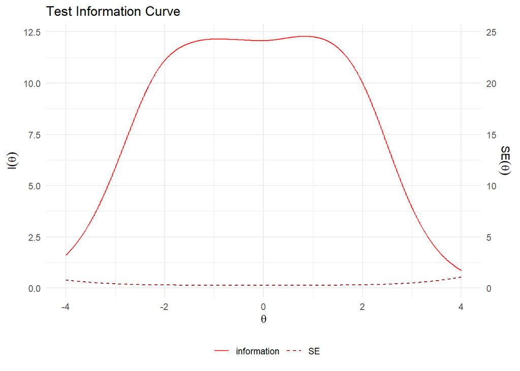

```r
testInfoPlot(fit_r, adj_factor = 2)
```

Test information shows high discrimination in a large theta range, with low standard error and a rather steep drop-off. This is a good thing for tests to have in general.

**Differential Item Functioning (DIF)** Looking at differences between genders (remember: we found a significant gender effect), I box-plotted the answers:

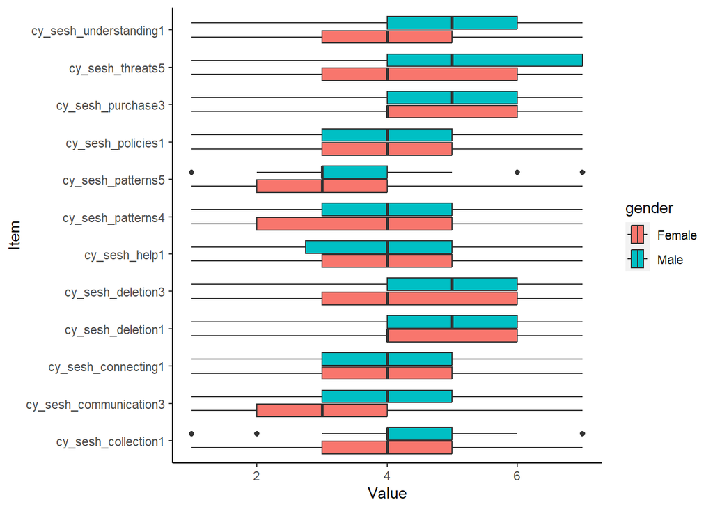

```r
#preparing data
rdata[,c(items, which(colnames(rdata)=="gender"))] |>
  pivot_longer(cols = colnames(rdata[items]), values_to = "Value", names_to = "Item") |>
#plotting
  ggplot()+
  aes(y=Item,x=Value, fill=gender)+
  geom_boxplot()+
  theme(panel.grid.major = element_blank(),
        panel.background = element_blank(),
        panel.grid.minor = element_blank(),
        axis.line = element_line(colour = "black"))
```

As we can see, Understanding1, threats5, and communication3 show large differences in variance and means. This could be an indicator as to why the coefficients were reordered.However, items policies1, connecting1 seem rather invariant to gender.

To test for this, we fit a multiple group object with `mirt` that is split by gender.

````markdown
```{r}
dif_gen_r <- multipleGroup(rdata[items], model = 1,
                         group = rdata$gender,
                         method = "MHRM",
                         invariance = c("cy_sesh_policies1", "cy_sesh_connecting1", "free_means", "free_variance"),
                         itemtype = "grsm")
dif_r <- DIF(dif_gen_r,
    which.par = c("a1", "c"),
    plotdif = T,
    simplify = T,
    verbose = T)
```
````

Then the object is tested for differential item functioning with the `DIF()` command.This also takes some time.

```r
dif_grsm
```

|  | groups | converged | AIC | SABIC | HQ | BIC | X2 | df | p |
| --- | --- | --- | --- | --- | --- | --- | --- | --- | --- |
| cy_sesh_policies1 | Female,Male | TRUE | 15.50690 | 17.20305 | 17.36185 | 20.37903 | -13.50690 | 1 | NaN |
| cy_sesh_deletion3 | Female,Male | TRUE | 15.28571 | 18.67800 | 18.99561 | 25.02997 | -11.28571 | 2 | NaN |
| cy_sesh_deletion1 | Female,Male | TRUE | 16.26633 | 19.65862 | 19.97622 | 26.01059 | -12.26633 | 2 | NaN |
| cy_sesh_communication3 | Female,Male | TRUE | 16.84542 | 20.23771 | 20.55531 | 26.58967 | -12.84542 | 2 | NaN |
| cy_sesh_collection1 | Female,Male | TRUE | 16.53216 | 19.92445 | 20.24206 | 26.27642 | -12.53216 | 2 | NaN |
| cy_sesh_understanding1 | Female,Male | TRUE | 15.91534 | 19.30763 | 19.62524 | 25.65960 | -11.91534 | 2 | NaN |
| cy_sesh_connecting1 | Female,Male | TRUE | 13.50690 | 13.50690 | 13.50690 | 13.50690 | -13.50690 | 0 | NaN |
| cy_sesh_patterns4 | Female,Male | TRUE | 17.45124 | 20.84353 | 21.16114 | 27.19550 | -13.45124 | 2 | NaN |
| cy_sesh_patterns5 | Female,Male | TRUE | 17.30777 | 20.70006 | 21.01767 | 27.05203 | -13.30777 | 2 | NaN |
| cy_sesh_help1 | Female,Male | TRUE | 17.40109 | 20.79338 | 21.11099 | 27.14535 | -13.40109 | 2 | NaN |
| cy_sesh_purchase3 | Female,Male | TRUE | 16.08976 | 19.48205 | 19.79965 | 25.83401 | -12.08976 | 2 | NaN |
| cy_sesh_threats5 | Female,Male | TRUE | 14.49794 | 17.89023 | 18.20784 | 24.24220 | -10.49794 | 2 | NaN |

We did not detect DIF in items between men and women.

# GPCM Analysis

**Notes on GPCM** This model is a generalization of the PCM (or RSM, those are identical models) in a similar manner than a 2-PL model is a generalization of the SML (or Rasch) Model. It includes a discrimination parameter and individually computes threshold parameters for the item answer options for each item (unlike the RSM, which computes one threshold parameter estimate for each option (every item has the same parameters). The GPCM is missing the (for Rasch hardliners) “crucial” assumption (!) of specific objectivity, which states that every logit difference between two persons per item is independent of measurement device and that every logit difference between items per person is independent of measurement device. I would think most psychologists would have the notion that this is completely bonkers to assume just from common psychological sense and I would agree. While our RSM fits better, we will still look at GPCM results as they can tell us a lot about underlying data structure and discrimination of items. Selecting items that ideally are best in both models will surely aid the future model. Note that our performance metrics are askew as we have a lot of items, and many models are not used to that large amount of items. We will copy the result structure from our RSM analysis part.

First, we look at the model summary and save it as a data frame for later.

```
                          F1     h2
cy_sesh_policies1      0.472 0.2224
cy_sesh_deletion3      0.393 0.1548
cy_sesh_deletion1      0.488 0.2379
cy_sesh_communication3 0.422 0.1777
cy_sesh_collection1    0.544 0.2961
cy_sesh_understanding1 0.278 0.0770
cy_sesh_connecting1    0.631 0.3982
cy_sesh_patterns4      0.342 0.1172
cy_sesh_patterns5      0.504 0.2542
cy_sesh_help1          0.229 0.0526
cy_sesh_purchase3      0.427 0.1820
cy_sesh_threats5       0.267 0.0715

SS loadings:  2.242
Proportion Var:  0.187

Factor correlations:

   F1
F1  1
```

F1 represents the factor loadings for each item, h2 represents the communality, i.e. how much of the item’s variance is explained by the latent factor.

Applying common standards in the field, items 12,6, and 10 would be excluded due to factor loadings < 0.3 and very low communalities (<0.1). The best items in terms of FL and communalities (top 3) would be 7,5 and 9.

Next, we look at parameters in our model. Note that a rating scale model assumes ordered items from bad to good, in a sense. again, we save it as a data frame for later

```r
ice <- coef(fit_g, simplify =T)|> as.data.frame()
ice
```

|  | items.a1 | items.b1 | items.b2 | items.b3 | items.b4 | items.b5 | items.b6 | items.c | means | F1 |
| --- | --- | --- | --- | --- | --- | --- | --- | --- | --- | --- |
| cy_sesh_policies1 | 0.9103457 | -1.977731 | -1.2222559 | -1.0395527 | 0.8660740 | 1.1756751 | 1.6328365 | 0 | 0 | 1 |
| cy_sesh_deletion3 | 0.7282618 | -1.849921 | -1.7733288 | -0.9804686 | 0.3967503 | 0.3451402 | 0.6832711 | 0 | 0 | 1 |
| cy_sesh_deletion1 | 0.9509706 | -2.093871 | -1.7849054 | -1.3160052 | 0.3267964 | 0.4830625 | 0.7437193 | 0 | 0 | 1 |
| cy_sesh_communication3 | 0.7912331 | -1.519797 | -0.8577805 | -0.0845948 | 1.3346096 | 1.5248222 | 1.1775919 | 0 | 0 | 1 |
| cy_sesh_collection1 | 1.1039300 | -1.632352 | -1.4164961 | -0.9853617 | 0.4172933 | 0.9859686 | 1.1950214 | 0 | 0 | 1 |
| cy_sesh_understanding1 | 0.4916227 | -1.655100 | -1.2706674 | -1.3545593 | 0.6975856 | 0.9504723 | 0.6909778 | 0 | 0 | 1 |
| cy_sesh_connecting1 | 1.3843454 | -1.799020 | -1.2376937 | -0.2961539 | 0.5839575 | 1.3289506 | 1.6086546 | 0 | 0 | 1 |
| cy_sesh_patterns4 | 0.6200515 | -1.552742 | -1.3172220 | -0.3854433 | 1.1896455 | 1.4077099 | 1.5738065 | 0 | 0 | 1 |
| cy_sesh_patterns5 | 0.9937776 | -1.432187 | -0.9384169 | 0.2161252 | 1.1125009 | 1.9332713 | 1.7289234 | 0 | 0 | 1 |
| cy_sesh_help1 | 0.4010806 | -1.838690 | -1.0847159 | -0.8206513 | 2.1371845 | 2.1141399 | -0.0467267 | 0 | 0 | 1 |
| cy_sesh_purchase3 | 0.8028094 | -1.832107 | -1.5846601 | -1.5924481 | 0.4608790 | 0.7465263 | 1.1321458 | 0 | 0 | 1 |
| cy_sesh_threats5 | 0.4723647 | -2.163911 | -1.5278735 | -1.7748006 | 0.6660444 | 0.2736960 | -0.3605598 | 0 | 0 | 1 |

a parameters represent item discriminination. b parameters represent the thresholds at which a person is about as likely to choose one or the next-lower option.

Next we assess model fit of the GPCM. This has been calculated beforehand, as covergence takes some time. The following code was used:

````markdown
```{r}
modfit <- M2(fit_g, type = "C2", calcNull = F)
```
````

```r
modfit
```

|  | M2 | df | p | RMSEA | RMSEA_5 | RMSEA_95 | SRMSR |
| --- | --- | --- | --- | --- | --- | --- | --- |
| stats | 301.7358 | 54 | 0 | 0.068772 | 0.0612831 | 0.0764019 | 0.0396987 |

Values of model fit are significantly worse than the RSM, except for SRMSR, which seems to be better. Note that this is the standard RMSEA, NOT the $RMSEA_2$, as proposed by Maydeu-Olivares & Joe (2014) for IRT Models. M2 statistic (similar function as $\chi^2$) is significant, meaning that it would reject the model. However, M2 does not work properly for large models like ours (also stated in Maydeu-Olivares & Joe (2014)).

To follow-up, we assess item fit. This is done with the ´itemfit()´command.

```r
itf <- itemfit(fit_g)
itf
```

| item | S_X2 | df.S_X2 | RMSEA.S_X2 | p.S_X2 |
| --- | --- | --- | --- | --- |
| cy_sesh_policies1 | 165.3710 | 158 | 0.0069351 | 0.3278904 |
| cy_sesh_deletion3 | 153.5938 | 173 | 0.0000000 | 0.8528801 |
| cy_sesh_deletion1 | 152.5187 | 148 | 0.0056103 | 0.3825922 |
| cy_sesh_communication3 | 150.7684 | 169 | 0.0000000 | 0.8396814 |
| cy_sesh_collection1 | 174.4232 | 152 | 0.0123322 | 0.1028363 |
| cy_sesh_understanding1 | 200.0831 | 197 | 0.0040168 | 0.4254100 |
| cy_sesh_connecting1 | 159.6755 | 137 | 0.0130627 | 0.0900231 |
| cy_sesh_patterns4 | 246.8005 | 186 | 0.0183574 | 0.0018889 |
| cy_sesh_patterns5 | 158.3992 | 155 | 0.0047548 | 0.4092502 |
| cy_sesh_help1 | 200.6373 | 199 | 0.0029124 | 0.4541240 |
| cy_sesh_purchase3 | 175.7988 | 162 | 0.0093708 | 0.2169173 |
| cy_sesh_threats5 | 116.4981 | 104 | 0.0111306 | 0.1894517 |

this computes the S<sub>X2</sub> statistic, which should not become significant for items in order to signify good fit. This will be discussed later on.

Finally, Let’s look at a plot for the whole model in terms of total scores in relation to theta.

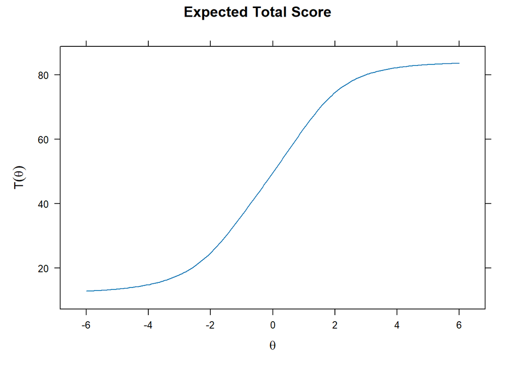

```r
plot(fit_g)
```

**Infit and Outfit**

Items usually are looked at in terms of infit and outfit statistics. In general, it is preferable to look at infit, which should be close to 1, and ideally less than 1. To visualize this for all items, we additionally use the `itemfitplot()` function from `ggmirt`.

```r
infi <- itemfit(fit_g, fit_stats = "infit") |> as.data.frame()
infi
```

| item | outfit | z.outfit | infit | z.infit |
| --- | --- | --- | --- | --- |
| cy_sesh_policies1 | 0.9104778 | -2.0083379 | 0.9180495 | -1.855328 |
| cy_sesh_deletion3 | 0.9431537 | -1.2926629 | 0.9106408 | -2.149383 |
| cy_sesh_deletion1 | 0.8856437 | -2.5501340 | 0.8992613 | -2.348728 |
| cy_sesh_communication3 | 0.9240943 | -1.7155210 | 0.9336695 | -1.504489 |
| cy_sesh_collection1 | 0.8665230 | -2.9712724 | 0.8855642 | -2.611852 |
| cy_sesh_understanding1 | 0.9739375 | -0.6203666 | 0.9499949 | -1.228782 |
| cy_sesh_connecting1 | 0.8444592 | -3.5509434 | 0.8549186 | -3.357937 |
| cy_sesh_patterns4 | 0.9499148 | -1.1651802 | 0.9450856 | -1.282263 |
| cy_sesh_patterns5 | 0.9009930 | -2.2469675 | 0.9118374 | -1.993892 |
| cy_sesh_help1 | 0.9729191 | -0.6338306 | 0.9561281 | -1.049748 |
| cy_sesh_purchase3 | 0.9229178 | -1.7421528 | 0.9326933 | -1.530735 |
| cy_sesh_threats5 | 0.9527029 | -1.1155442 | 0.9539243 | -1.146563 |

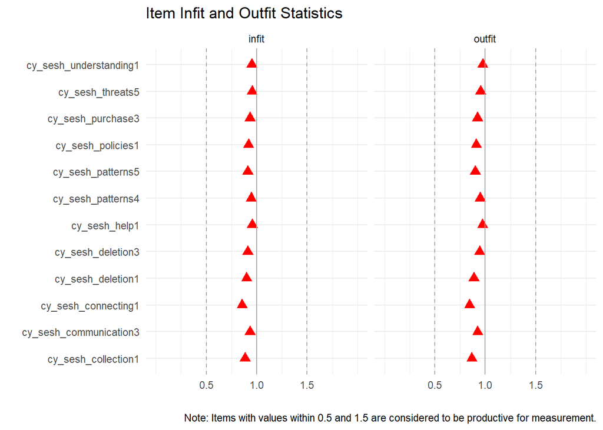

```r
itemfitPlot(fit_g)
```

As one can see from these data, our items seem to be better in regard to infit than the RSM values (lower beyond 1). Still nothing problematic in both camps.

**Person Fit**

To calculate whether the persons fit the model, we use person fit statistics. We calculate proportions of infit and outfit in persons using z-scores. Higher non-fitting rates than 5% are considered worrying.

```r
personfit(fit_g) |>
  reframe(infit.outside = prop.table(table(z.infit > 1.96 | z.infit < -1.96)),
          outfit.outside = prop.table(table(z.outfit>1.96 | z.outfit < -1.96)))
```

| infit.outside | outfit.outside |
| --- | --- |
| 0.7723996 | 0.753862 |
| 0.2276004 | 0.246138 |

This shows similar patterns as the RSM model, albeit slightly higher non-fitting person ratios (second row) than the RSM, which might explain the worse model-data fit.

To further investigate this, we can plot the factor scores.

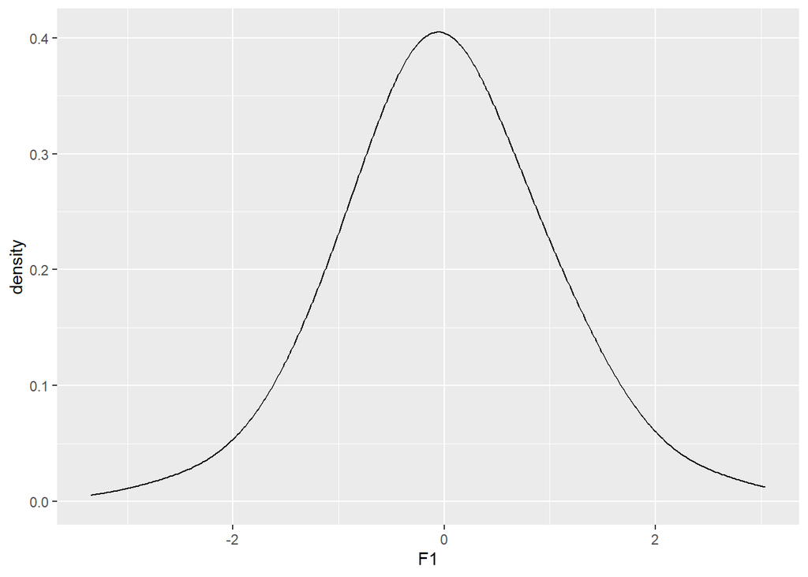

```r
fscores(fit_g) |> as.data.frame() |> ggplot(aes(F1))+geom_density(bw=0.5)
```

This is a smoothed kernel density plot of estimated factor scores of all persons in the data set. As we can see, extreme ends are fatter than would be expected with gaussian extremes.

Let’s look at an un-smoothed version of this.

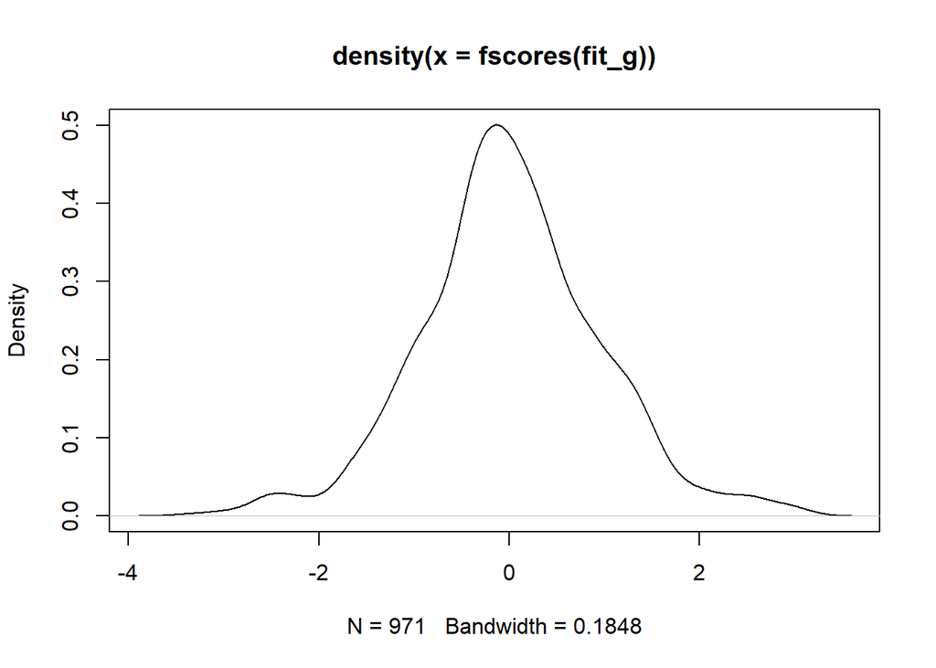

```r
fscores(fit_g) |> density() |> plot()
```

The plot clearly shows outliers at the extreme ends in both directions. The question remains whether this was a sampling problem or a modeling issue - this can only be solved by further sampling.

**Graphic Item Analysis**

Item analysis is done graphically and numerically with a final table. This is done to assess item quality for scale reduction. First, lets look at option characteristic curves (OCCs) for each item.

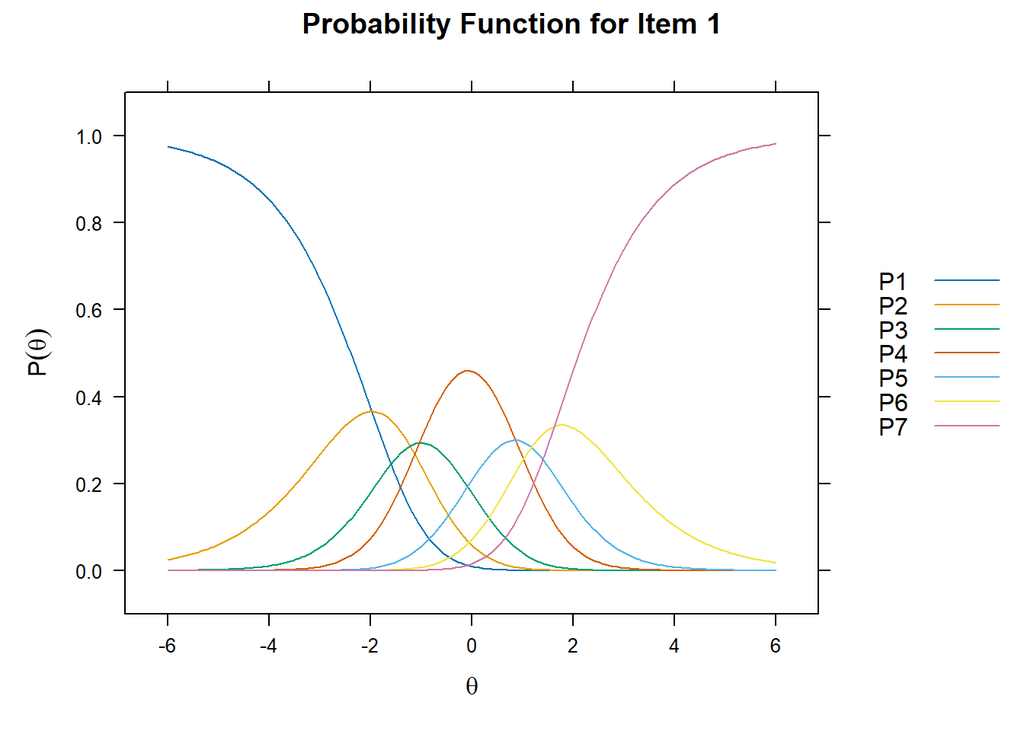

```r
#Option characteristic curves
itemplot(fit_g, item = 1)
```

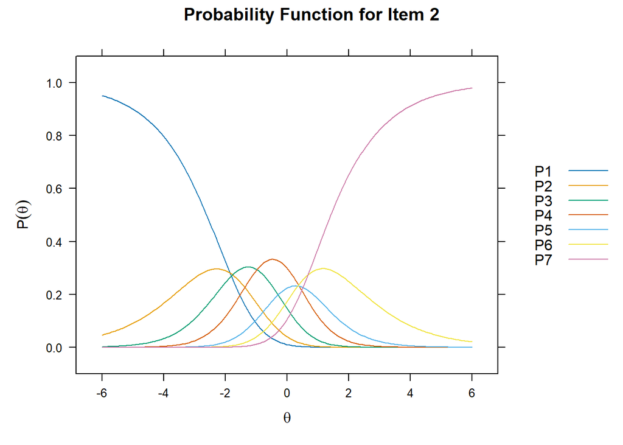

```r
itemplot(fit_g, item = 2)
```

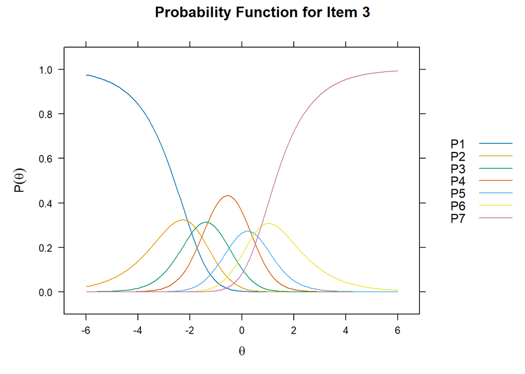

```r
itemplot(fit_g, item = 3)
```

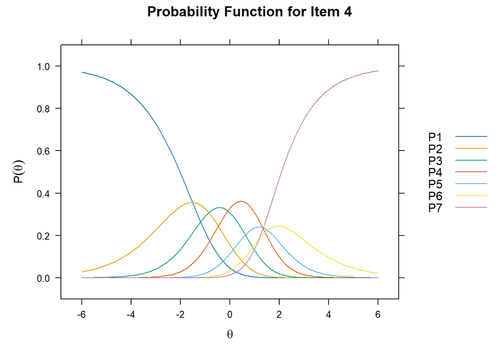

```r
itemplot(fit_g, item = 4)
```

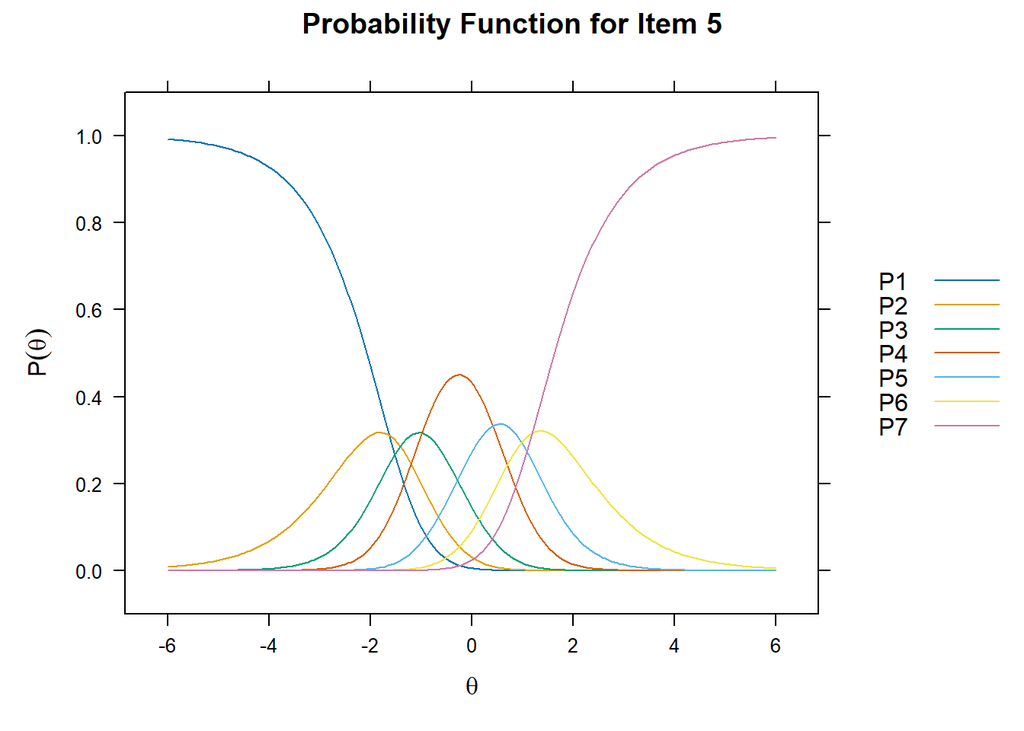

```r
itemplot(fit_g, item = 5)
```

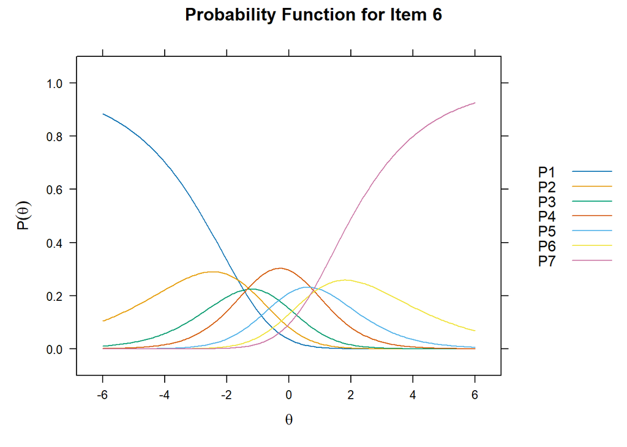

```r
itemplot(fit_g, item = 6)
```

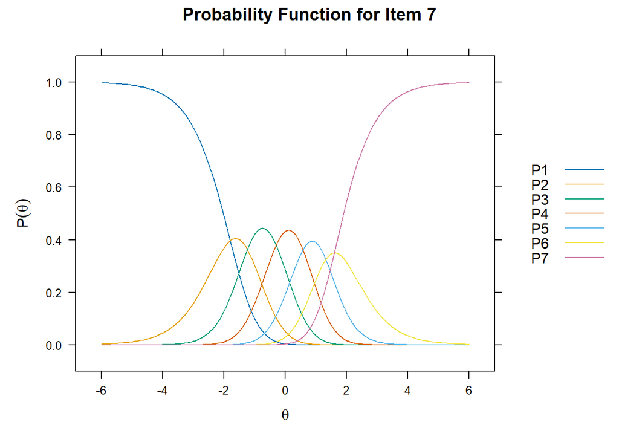

```r
itemplot(fit_g, item = 7)
```

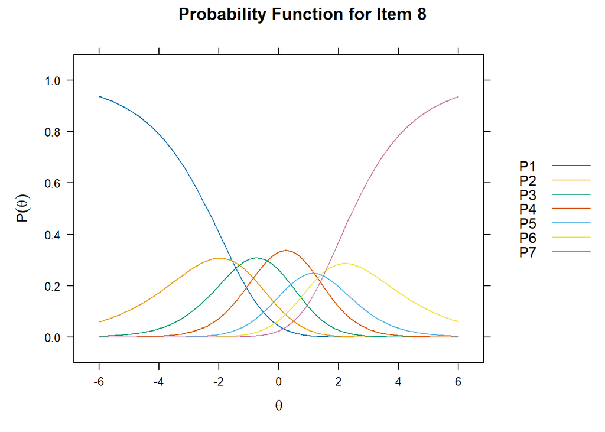

```r
itemplot(fit_g, item = 8)
```

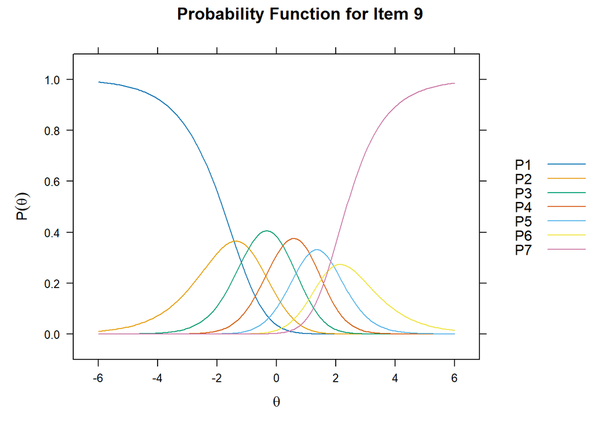

```r
itemplot(fit_g, item = 9)
```

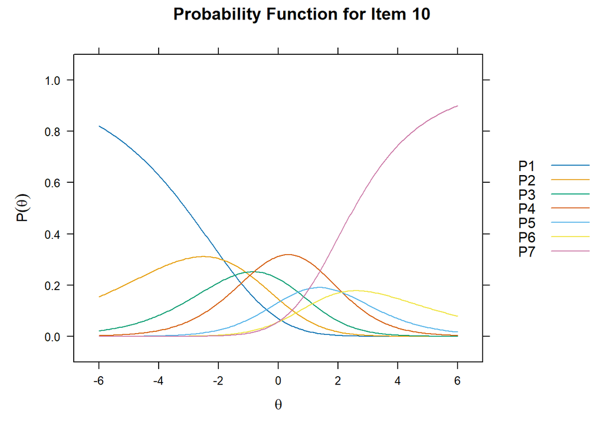

```r
itemplot(fit_g, item = 10)
```

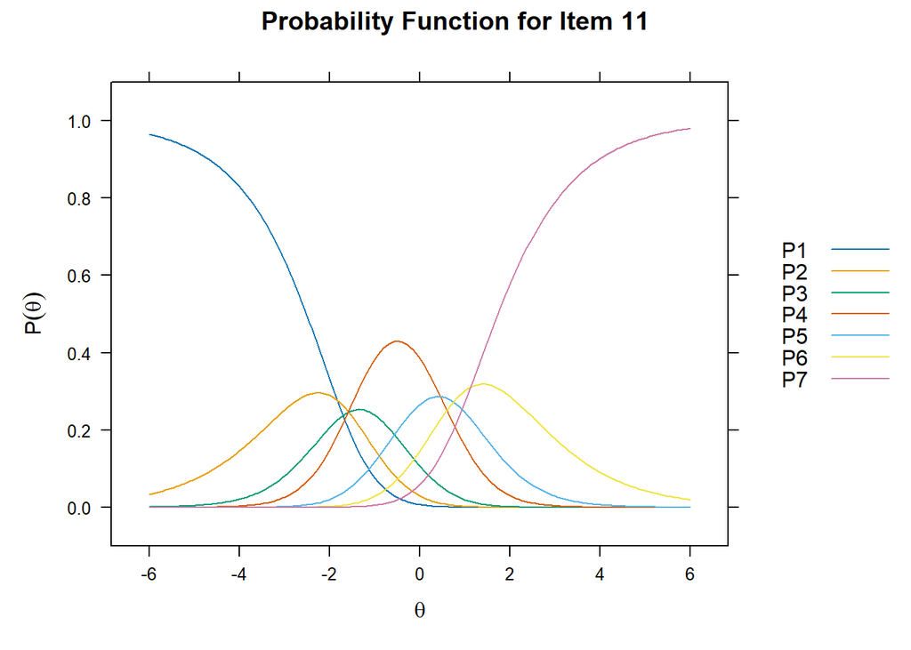

```r
itemplot(fit_g, item = 11)
```

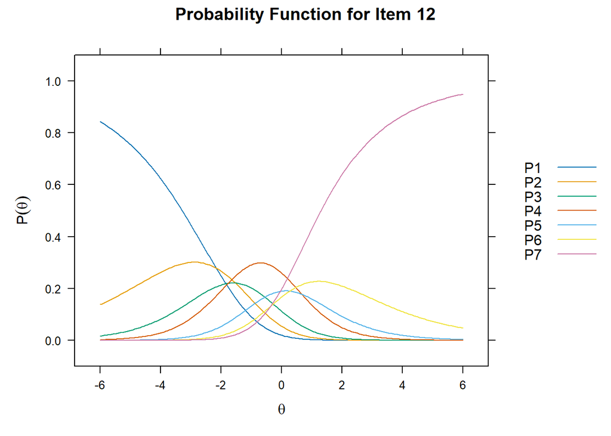

```r
itemplot(fit_g, item = 12)
```

Additionally, we can plot the item information function for each item.

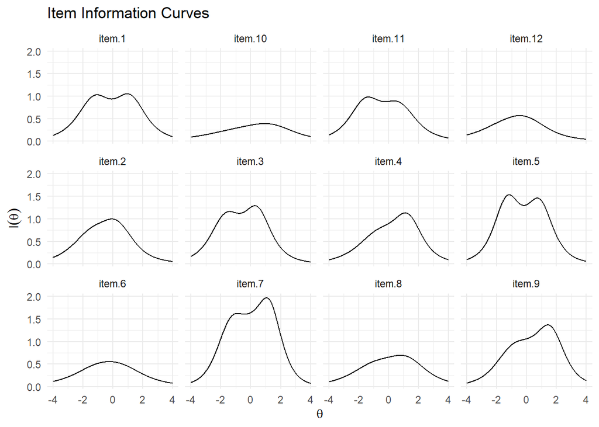

```r
itemInfoPlot(fit_g, facet = T)
```

```r
itemjudge2 <- data.frame(
  item = row.names(ice),
  communality = round(smr$h2, digits = 2),
  p.S_x2 = round(itf$p.S_X2, digits = 2),
  discr=round(ice$items.a1, digits = 2),
  infit= round(infi$infit, digits = 2)
)
itemjudge2
```

| item | communality | p.S_x2 | discr | infit |
| --- | --- | --- | --- | --- |
| cy_sesh_policies1 | 0.22 | 0.33 | 0.91 | 0.92 |
| cy_sesh_deletion3 | 0.15 | 0.85 | 0.73 | 0.91 |
| cy_sesh_deletion1 | 0.24 | 0.38 | 0.95 | 0.90 |
| cy_sesh_communication3 | 0.18 | 0.84 | 0.79 | 0.93 |
| cy_sesh_collection1 | 0.30 | 0.10 | 1.10 | 0.89 |
| cy_sesh_understanding1 | 0.08 | 0.43 | 0.49 | 0.95 |
| cy_sesh_connecting1 | 0.40 | 0.09 | 1.38 | 0.85 |
| cy_sesh_patterns4 | 0.12 | 0.00 | 0.62 | 0.95 |
| cy_sesh_patterns5 | 0.25 | 0.41 | 0.99 | 0.91 |
| cy_sesh_help1 | 0.05 | 0.45 | 0.40 | 0.96 |
| cy_sesh_purchase3 | 0.18 | 0.22 | 0.80 | 0.93 |
| cy_sesh_threats5 | 0.07 | 0.19 | 0.47 | 0.95 |

This in conjunction with the item information plots and the OCCs should be used to select possible candidate items for a short scale.

**Test Information**

Finally, a test information plot is made to show at which regions of theta the test can discriminate well.

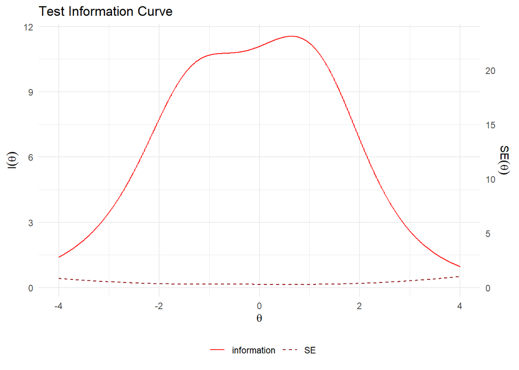

```r
testInfoPlot(fit_g, adj_factor = 2)
```

Test information shows high discrimination in a large theta range, with low standard error and a rather steep drop-off. This is a good thing for tests to have in general.

**Differential Item Functioning (DIF)**

To test for this, we fit a multiple group object with `mirt` that is split by gender.Then the object is tested for differential item functioning with the `DIF()` command. This also takes some time.

````markdown
```{r}
dif_gen <- multipleGroup(xdata[2:13], model = 1,
                         group = xdata$gender,
                         method = "MHRM",
                         invariance = c("cy_sesh_policies1", "cy_sesh_connecting1", "free_means", "free_variance"),
                         itemtype = "gpcm")
dif <- DIF(dif_gen,
    which.par = c("a1", "c"),
    scheme = "add",
    Wald = T,
    seq_stat = "BIC",
    plotdif = T,
    simplify = T,
    verbose = T)
```
````

```r
dif
```

|  | groups | converged | AIC | SABIC | HQ | BIC | X2 | df | p |
| --- | --- | --- | --- | --- | --- | --- | --- | --- | --- |
| cy_sesh_policies1 | Female,Male | TRUE | 193.9850 | 195.6812 | 195.8400 | 198.8572 | -191.9850 | 1 | NaN |
| cy_sesh_deletion3 | Female,Male | TRUE | 194.6762 | 196.3724 | 196.5312 | 199.5483 | -192.6762 | 1 | NaN |
| cy_sesh_deletion1 | Female,Male | TRUE | 192.2744 | 193.9705 | 194.1293 | 197.1465 | -190.2744 | 1 | NaN |
| cy_sesh_communication3 | Female,Male | TRUE | 191.1038 | 192.7999 | 192.9587 | 195.9759 | -189.1038 | 1 | NaN |
| cy_sesh_collection1 | Female,Male | TRUE | 191.3914 | 193.0875 | 193.2463 | 196.2635 | -189.3914 | 1 | NaN |
| cy_sesh_understanding1 | Female,Male | TRUE | 194.1015 | 195.7977 | 195.9565 | 198.9737 | -192.1015 | 1 | NaN |
| cy_sesh_connecting1 | Female,Male | TRUE | 194.5980 | 196.2941 | 196.4529 | 199.4701 | -192.5980 | 1 | NaN |
| cy_sesh_patterns4 | Female,Male | TRUE | 194.2844 | 195.9806 | 196.1394 | 199.1566 | -192.2844 | 1 | NaN |
| cy_sesh_patterns5 | Female,Male | TRUE | 194.9763 | 196.6724 | 196.8312 | 199.8484 | -192.9763 | 1 | NaN |
| cy_sesh_help1 | Female,Male | TRUE | 192.9767 | 192.9767 | 192.9767 | 192.9767 | -192.9767 | 0 | NaN |
| cy_sesh_purchase3 | Female,Male | TRUE | 194.3103 | 196.0064 | 196.1652 | 199.1824 | -192.3103 | 1 | NaN |
| cy_sesh_threats5 | Female,Male | TRUE | 192.0903 | 193.7864 | 193.9452 | 196.9624 | -190.0903 | 1 | NaN |